# Analysis of exposures without a discourse context (canonical markings not used for generation)

This notebook analyzes the generalization patterns of novel dative-verb learners based on the factors of exposure contexts which situate the novel verb in a neutral discourse context where only the agent is given. For example:

```
DO: mommy [verbed] me a ball.
PP: mommy [verbed] a ball to me .
```

## Loading Data (code hidden)

```
 Found 500 records...
 Found 1000 records...
 Found 1500 records...
 Found 1620 records...
 Imported 1620 records. Simplifying...

 Found 255 records...
 Imported 255 records. Simplifying...
```

## Cross Dative Generalization

Investigating alternate-form generalization patterns of the learner when it is exposed to the double object dative vs. prepositional object dative.

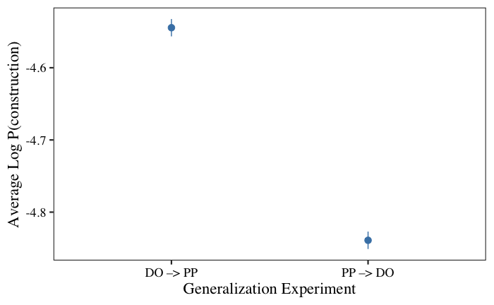

## Conwell’s “me” finding (2019):

Pronominal recipients enable DO comprehension in children, so if we were to believe that comprehension is a precondition to generalization, then pronominal recipients should also encourage generalization:

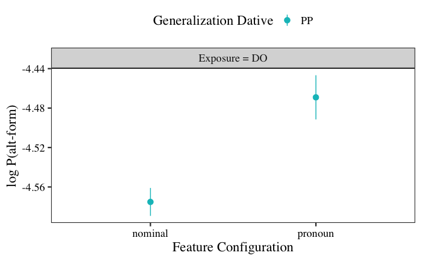

## Replicating Arunachalam (2017):

Only looking at definite themes and recipients:

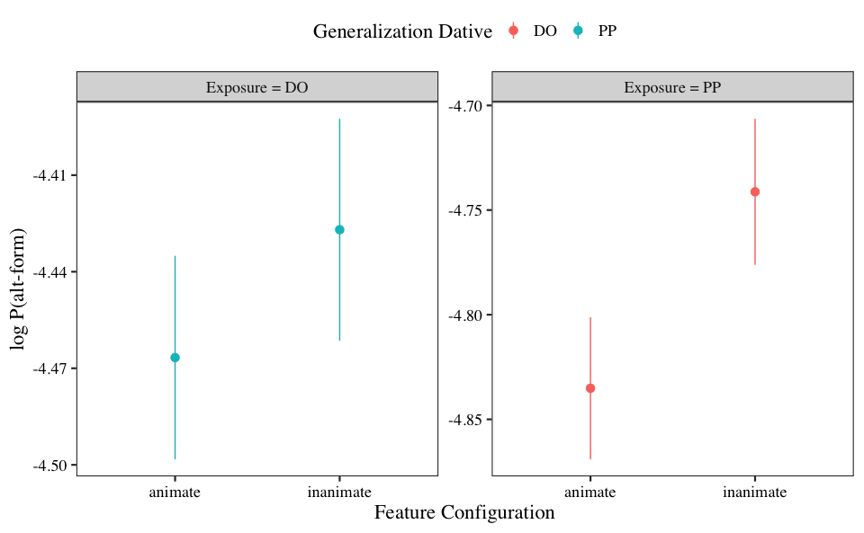

## Interaction terms

The design of interaction terms is a bit tricky. Due to our design, the pronominality might interact with the animacy of a given argument, but animacy and pronominality might also interact across arguments – e.g., if theme is inanimate then LMs might prefer animate recipients (if they are sensitive to the semantics of the dative construction – caused possession/motion). This means we should include the following interaction terms:

```
- theme_animacy * theme_pronominality
- recipient_animacy * recipient_pronominality
- theme_animacy * recipient_animacy
- theme_pronominality * recipient pronominality
```

## DO –> PP analysis

```r
do_pp <- coded_results %>%
  filter(adaptation_dative == "do", generalization_dative == "pp")

# interactions between theme-animacy and recipient animacy; theme-pronominality and recipient-pronominality

fit_tara_tprp_interaction_dopp <- lmer(best ~
                                    theme_animacy * theme_pronominality +
                                    recipient_animacy * recipient_pronominality +
                                    theme_animacy * recipient_animacy +
                                    theme_pronominality * recipient_pronominality +
                                    theme_definiteness + recipient_definiteness +
                                    theme_length  + recipient_length +
                                    (1|model) + (1|item_id), data = do_pp)

summary(fit_tara_tprp_interaction_dopp, correlation = FALSE)
```

```
Linear mixed model fit by REML. t-tests use Satterthwaite's method ['lmerModLmerTest']
Formula: best ~ theme_animacy * theme_pronominality + recipient_animacy *
    recipient_pronominality + theme_animacy * recipient_animacy +
    theme_pronominality * recipient_pronominality + theme_definiteness +
    recipient_definiteness + theme_length + recipient_length +      (1 | model) + (1 | item_id)
   Data: do_pp

REML criterion at convergence: 11567

Scaled residuals:
    Min      1Q  Median      3Q     Max
-5.4005 -0.6305  0.0841  0.7062  2.6395

Random effects:
 Groups   Name        Variance Std.Dev.
 item_id  (Intercept) 0.04561  0.2136
 model    (Intercept) 0.02388  0.1545
 Residual             0.21521  0.4639
Number of obs: 8100, groups:  item_id, 810; model, 10

Fixed effects:
                                              Estimate Std. Error         df t value Pr(>|t|)
(Intercept)                                  -4.570924   0.051096  10.517234 -89.458  < 2e-16 ***
theme_animacy                                -0.120235   0.020384 796.999986  -5.898 5.42e-09 ***
theme_pronominality                          -0.044162   0.027799 796.999986  -1.589 0.112544
recipient_animacy                             0.101654   0.020384 796.999986   4.987 7.53e-07 ***
recipient_pronominality                       0.058216   0.027799 796.999985   2.094 0.036558 *
theme_definiteness                            0.026190   0.018311 796.999986   1.430 0.153026
recipient_definiteness                        0.138374   0.018311 796.999986   7.557 1.14e-13 ***
theme_length                                  0.012279   0.021592 796.999986   0.569 0.569734
recipient_length                              0.154525   0.021592 796.999985   7.157 1.88e-12 ***
theme_animacy:theme_pronominality             0.005412   0.040768 796.999986   0.133 0.894427
recipient_animacy:recipient_pronominality     0.156888   0.040768 796.999986   3.848 0.000128 ***
theme_animacy:recipient_animacy              -0.181808   0.036525 796.999986  -4.978 7.89e-07 ***
theme_pronominality:recipient_pronominality   0.185387   0.051234 796.999986   3.618 0.000315 ***
---
Signif. codes:  0 ‘***’ 0.001 ‘**’ 0.01 ‘*’ 0.05 ‘.’ 0.1 ‘ ’ 1
```

## PP –> DO Analysis

```r
pp_do <- coded_results %>%
  filter(adaptation_dative == "pp", generalization_dative == "do")

fit_tara_tprp_interaction_ppdo <- lmer(best ~
                                    theme_animacy * theme_pronominality +
                                    recipient_animacy * recipient_pronominality +
                                    theme_animacy * recipient_animacy +
                                    theme_pronominality * recipient_pronominality +
                                    theme_definiteness + recipient_definiteness +
                                    theme_length  + recipient_length +
                                    (1|model) + (1|item_id), data = pp_do)

summary(fit_tara_tprp_interaction_ppdo, correlation = FALSE)
```

```
Linear mixed model fit by REML. t-tests use Satterthwaite's method ['lmerModLmerTest']
Formula: best ~ theme_animacy * theme_pronominality + recipient_animacy *
    recipient_pronominality + theme_animacy * recipient_animacy +
    theme_pronominality * recipient_pronominality + theme_definiteness +
    recipient_definiteness + theme_length + recipient_length +      (1 | model) + (1 | item_id)
   Data: pp_do

REML criterion at convergence: 11754.1

Scaled residuals:
    Min      1Q  Median      3Q     Max
-8.7323 -0.5904  0.1067  0.7007  2.4531

Random effects:
 Groups   Name        Variance Std.Dev.
 item_id  (Intercept) 0.04109  0.2027
 model    (Intercept) 0.02274  0.1508
 Residual             0.22225  0.4714
Number of obs: 8100, groups:  item_id, 810; model, 10

Fixed effects:
                                             Estimate Std. Error        df t value Pr(>|t|)
(Intercept)                                  -4.85571    0.04984  10.48128 -97.433  < 2e-16 ***
theme_animacy                                -0.09014    0.01980 796.99185  -4.553 6.10e-06 ***
theme_pronominality                           0.06815    0.02700 796.99185   2.524 0.011786 *
recipient_animacy                             0.01569    0.01980 796.99185   0.793 0.428262
recipient_pronominality                       0.11202    0.02700 796.99185   4.149 3.69e-05 ***
theme_definiteness                            0.03006    0.01778 796.99185   1.690 0.091348 .
recipient_definiteness                        0.06207    0.01778 796.99185   3.490 0.000509 ***
theme_length                                  0.26084    0.02097 796.99185  12.439  < 2e-16 ***
recipient_length                              0.10570    0.02097 796.99185   5.041 5.74e-07 ***
theme_animacy:theme_pronominality            -0.12810    0.03959 796.99185  -3.235 0.001265 **
recipient_animacy:recipient_pronominality    -0.05291    0.03959 796.99185  -1.336 0.181844
theme_animacy:recipient_animacy              -0.05821    0.03547 796.99185  -1.641 0.101192
theme_pronominality:recipient_pronominality   0.19243    0.04976 796.99185   3.867 0.000119 ***
---
Signif. codes:  0 ‘***’ 0.001 ‘**’ 0.01 ‘*’ 0.05 ‘.’ 0.1 ‘ ’ 1
```

## Attempt at displaying DO -> PP and PP -> DO in same table:

```r
tidy(fit_tara_tprp_interaction_dopp) %>%
  filter(effect == "fixed") %>%
  select(term, do_pp_estimate = estimate, do_pp_pval = p.value) %>%
  inner_join(
    tidy(fit_tara_tprp_interaction_ppdo) %>%
      filter(effect == "fixed") %>%
      select(term, pp_do_estimate = estimate, pp_do_pval = p.value)
  ) %>%
  mutate(
    # do_pp_estimate = format(do_pp_estimate , scientific=TRUE),
    # pp_do_estimate = format(pp_do_estimate, scientific=TRUE),
    do_pp_estimate = round(do_pp_estimate, 4),
    pp_do_estimate = round(pp_do_estimate, 4),
    do_pp_signif = case_when(
      do_pp_pval < 0.05 ~ "**",
      TRUE ~ as.character(round(do_pp_pval, 4))
    ),
    pp_do_signif = case_when(
      pp_do_pval < 0.05 ~ "**",
      TRUE ~ as.character(round(pp_do_pval, 4))
    )
  ) %>%
  select(term, do_pp_estimate, do_pp_signif, pp_do_estimate, pp_do_signif) %>%
  DT::datatable(options = list(pageLength = 14))
```

|  | term | do_pp_estimate | do_pp_signif | pp_do_estimate | pp_do_signif |
| --- | --- | --- | --- | --- | --- |
| 1 | (Intercept) | -4.5709 | ** | -4.8557 | ** |
| 2 | theme_animacy | -0.1202 | ** | -0.0901 | ** |
| 3 | theme_pronominality | -0.0442 | 0.1125 | 0.0681 | ** |
| 4 | recipient_animacy | 0.1017 | ** | 0.0157 | 0.4283 |
| 5 | recipient_pronominality | 0.0582 | ** | 0.112 | ** |
| 6 | theme_definiteness | 0.0262 | 0.153 | 0.0301 | 0.0913 |
| 7 | recipient_definiteness | 0.1384 | ** | 0.0621 | ** |
| 8 | theme_length | 0.0123 | 0.5697 | 0.2608 | ** |
| 9 | recipient_length | 0.1545 | ** | 0.1057 | ** |
| 10 | theme_animacy:theme_pronominality | 0.0054 | 0.8944 | -0.1281 | ** |

[output cut: 3 more lines]

## LMER for Arunachalam (2017)

```r
do_pp_sudha <- sudha %>%
  filter(adaptation_dative == "do", generalization_dative == "pp")

# interactions between theme-animacy and recipient animacy; theme-pronominality and recipient-pronominality

fit_tara_tprp_interaction_dopp_sudha <- lmer(best ~
                                    theme_animacy * theme_pronominality +
                                    recipient_animacy * recipient_pronominality +
                                    theme_animacy * recipient_animacy +
                                    theme_pronominality * recipient_pronominality +
                                    theme_length  + recipient_length +
                                    (1|model) + (1|item_id), data = do_pp_sudha)

summary(fit_tara_tprp_interaction_dopp_sudha, correlation = FALSE)
```

```
Linear mixed model fit by REML. t-tests use Satterthwaite's method ['lmerModLmerTest']
Formula: best ~ theme_animacy * theme_pronominality + recipient_animacy *
    recipient_pronominality + theme_animacy * recipient_animacy +
    theme_pronominality * recipient_pronominality + theme_length +      recipient_length + (1 | model) + (1 | item_id)
   Data: do_pp_sudha

REML criterion at convergence: 2955.2

Scaled residuals:
    Min      1Q  Median      3Q     Max
-5.4290 -0.6449  0.0814  0.6997  2.2764

Random effects:
 Groups   Name        Variance Std.Dev.
 item_id  (Intercept) 0.03132  0.1770
 model    (Intercept) 0.02503  0.1582
 Residual             0.21141  0.4598
Number of obs: 2100, groups:  item_id, 210; model, 10

Fixed effects:
                                             Estimate Std. Error        df t value Pr(>|t|)
(Intercept)                                  -4.46194    0.05526  12.35757 -80.742  < 2e-16 ***
theme_animacy                                -0.02590    0.03467 199.00023  -0.747   0.4559
theme_pronominality                          -0.01125    0.04289 199.00023  -0.262   0.7934
recipient_animacy                             0.08538    0.03467 199.00023   2.463   0.0146 *
recipient_pronominality                       0.20047    0.04289 199.00023   4.674 5.44e-06 ***
theme_length                                  0.06316    0.03817 199.00023   1.654   0.0996 .
recipient_length                              0.20692    0.03817 199.00023   5.421 1.71e-07 ***
theme_animacy:theme_pronominality             0.11102    0.06934 199.00023   1.601   0.1110
recipient_animacy:recipient_pronominality     0.05540    0.06934 199.00023   0.799   0.4253
theme_animacy:recipient_animacy              -0.29982    0.06388 199.00023  -4.694 4.98e-06 ***
theme_pronominality:recipient_pronominality   0.14360    0.07682 199.00023   1.869   0.0630 .
---
Signif. codes:  0 ‘***’ 0.001 ‘**’ 0.01 ‘*’ 0.05 ‘.’ 0.1 ‘ ’ 1
```

```r
pp_do_sudha <- sudha %>%
  filter(adaptation_dative == "pp", generalization_dative == "do")

# interactions between theme-animacy and recipient animacy; theme-pronominality and recipient-pronominality

fit_tara_tprp_interaction_ppdo_sudha <- lmer(best ~
                                    theme_animacy * theme_pronominality +
                                    recipient_animacy * recipient_pronominality +
                                    theme_animacy * recipient_animacy +
                                    theme_pronominality * recipient_pronominality +
                                    theme_length  + recipient_length +
                                    (1|model) + (1|item_id), data = pp_do_sudha)

summary(fit_tara_tprp_interaction_ppdo_sudha, correlation = FALSE)
```

```
Linear mixed model fit by REML. t-tests use Satterthwaite's method ['lmerModLmerTest']
Formula: best ~ theme_animacy * theme_pronominality + recipient_animacy *
    recipient_pronominality + theme_animacy * recipient_animacy +
    theme_pronominality * recipient_pronominality + theme_length +      recipient_length + (1 | model) + (1 | item_id)
   Data: pp_do_sudha

REML criterion at convergence: 3032.2

Scaled residuals:
    Min      1Q  Median      3Q     Max
-4.2890 -0.5744  0.0963  0.7033  2.3176

Random effects:
 Groups   Name        Variance Std.Dev.
 item_id  (Intercept) 0.03810  0.1952
 model    (Intercept) 0.02294  0.1515
 Residual             0.21730  0.4661
Number of obs: 2100, groups:  item_id, 210; model, 10

Fixed effects:
                                             Estimate Std. Error        df t value Pr(>|t|)
(Intercept)                                  -4.80032    0.05406  13.33121 -88.800  < 2e-16 ***
theme_animacy                                -0.17978    0.03703 199.00076  -4.855 2.43e-06 ***
theme_pronominality                           0.18928    0.04581 199.00076   4.132 5.29e-05 ***
recipient_animacy                             0.05432    0.03703 199.00076   1.467  0.14393
recipient_pronominality                       0.13556    0.04581 199.00076   2.960  0.00345 **
theme_length                                  0.26377    0.04077 199.00076   6.470 7.44e-10 ***
recipient_length                              0.19484    0.04077 199.00076   4.779 3.41e-06 ***
theme_animacy:theme_pronominality            -0.32881    0.07406 199.00076  -4.440 1.49e-05 ***
recipient_animacy:recipient_pronominality    -0.19133    0.07406 199.00076  -2.584  0.01050 *
theme_animacy:recipient_animacy              -0.05657    0.06821 199.00076  -0.829  0.40791
theme_pronominality:recipient_pronominality   0.19330    0.08204 199.00076   2.356  0.01944 *
---
Signif. codes:  0 ‘***’ 0.001 ‘**’ 0.01 ‘*’ 0.05 ‘.’ 0.1 ‘ ’ 1
```

```r
tidy(fit_tara_tprp_interaction_dopp_sudha) %>%
  filter(effect == "fixed") %>%
  select(term, do_pp_estimate = estimate, do_pp_pval = p.value) %>%
  inner_join(
    tidy(fit_tara_tprp_interaction_ppdo_sudha) %>%
      filter(effect == "fixed") %>%
      select(term, pp_do_estimate = estimate, pp_do_pval = p.value)
  ) %>%
  mutate(
    # do_pp_estimate = format(do_pp_estimate , scientific=TRUE),
    # pp_do_estimate = format(pp_do_estimate, scientific=TRUE),
    do_pp_estimate = round(do_pp_estimate, 4),
    pp_do_estimate = round(pp_do_estimate, 4),
    do_pp_signif = case_when(
      do_pp_pval < 0.05 ~ "**",
      TRUE ~ as.character(round(do_pp_pval, 4))
    ),
    pp_do_signif = case_when(
      pp_do_pval < 0.05 ~ "**",
      TRUE ~ as.character(round(pp_do_pval, 4))
    )
  ) %>%
  select(term, do_pp_estimate, do_pp_signif, pp_do_estimate, pp_do_signif) %>%
  DT::datatable(options = list(pageLength = 14))
```

|  | term | do_pp_estimate | do_pp_signif | pp_do_estimate | pp_do_signif |
| --- | --- | --- | --- | --- | --- |
| 1 | (Intercept) | -4.4619 | ** | -4.8003 | ** |
| 2 | theme_animacy | -0.0259 | 0.4559 | -0.1798 | ** |
| 3 | theme_pronominality | -0.0112 | 0.7934 | 0.1893 | ** |
| 4 | recipient_animacy | 0.0854 | ** | 0.0543 | 0.1439 |
| 5 | recipient_pronominality | 0.2005 | ** | 0.1356 | ** |
| 6 | theme_length | 0.0632 | 0.0996 | 0.2638 | ** |
| 7 | recipient_length | 0.2069 | ** | 0.1948 | ** |
| 8 | theme_animacy:theme_pronominality | 0.111 | 0.111 | -0.3288 | ** |
| 9 | recipient_animacy:recipient_pronominality | 0.0554 | 0.4253 | -0.1913 | ** |
| 10 | theme_animacy:recipient_animacy | -0.2998 | ** | -0.0566 | 0.4079 |

[output cut: 1 more lines]